# CMTH642 Assignment 3

Geoffrey Clark

April 11, 2018

## Data Prep

Preparation: The dataset is related to white Portuguese “Vinh o Verde” wine. For more info: https://archive.ics.uci.edu/ml/datasets/Wine+Quality

Import to R the following file: http://archive.ics.uci.edu/ml/machine-learning-databases/wine-quality/winequality-white.csv

```r
# Download remote content
# wine.df <- read.csv("http://archive.ics.uci.edu/ml/machine-learning-databases/wine-quality/winequality-white.csv", header=T, sep=";")
wine.df <- read.csv("winequality-white.csv", header=T, sep=";")
```

## QUESTIONS

### 1. Check data characteristics. Is there missing data?

```r
sum(is.na(wine.df)) #0
```

```
## [1] 0
```

```r
str(wine.df)
```

```
## 'data.frame':    4898 obs. of  12 variables:
##  $ fixed.acidity       : num  7 6.3 8.1 7.2 7.2 8.1 6.2 7 6.3 8.1 ...
##  $ volatile.acidity    : num  0.27 0.3 0.28 0.23 0.23 0.28 0.32 0.27 0.3 0.22 ...
##  $ citric.acid         : num  0.36 0.34 0.4 0.32 0.32 0.4 0.16 0.36 0.34 0.43 ...
##  $ residual.sugar      : num  20.7 1.6 6.9 8.5 8.5 6.9 7 20.7 1.6 1.5 ...
##  $ chlorides           : num  0.045 0.049 0.05 0.058 0.058 0.05 0.045 0.045 0.049 0.044 ...
##  $ free.sulfur.dioxide : num  45 14 30 47 47 30 30 45 14 28 ...
##  $ total.sulfur.dioxide: num  170 132 97 186 186 97 136 170 132 129 ...
##  $ density             : num  1.001 0.994 0.995 0.996 0.996 ...
##  $ pH                  : num  3 3.3 3.26 3.19 3.19 3.26 3.18 3 3.3 3.22 ...
##  $ sulphates           : num  0.45 0.49 0.44 0.4 0.4 0.44 0.47 0.45 0.49 0.45 ...
##  $ alcohol             : num  8.8 9.5 10.1 9.9 9.9 10.1 9.6 8.8 9.5 11 ...
##  $ quality             : int  6 6 6 6 6 6 6 6 6 6 ...
```

```r
sapply(wine.df, function(x) sum(is.na(x))) # 0 NAs
```

```
##        fixed.acidity     volatile.acidity          citric.acid
##                    0                    0                    0
##       residual.sugar            chlorides  free.sulfur.dioxide
##                    0                    0                    0
## total.sulfur.dioxide              density                   pH
##                    0                    0                    0
##            sulphates              alcohol              quality
##                    0                    0                    0
```

```r
sapply(wine.df, function(x) sum(is.null(x))) # 0 NULLs
```

```
##        fixed.acidity     volatile.acidity          citric.acid
##                    0                    0                    0
##       residual.sugar            chlorides  free.sulfur.dioxide
##                    0                    0                    0
## total.sulfur.dioxide              density                   pH
##                    0                    0                    0
##            sulphates              alcohol              quality
##                    0                    0                    0
```

### 2. What is the correlation between the attributes other than wine quality?

```r
# For Visualizing Correlation:
# install.packages("corrplot")
library(corrplot)
(wine.cor <- cor(wine.df[,-12]))
```

```
##                      fixed.acidity volatile.acidity citric.acid
## fixed.acidity           1.00000000      -0.02269729  0.28918070
## volatile.acidity       -0.02269729       1.00000000 -0.14947181
## citric.acid             0.28918070      -0.14947181  1.00000000
## residual.sugar          0.08902070       0.06428606  0.09421162
## chlorides               0.02308564       0.07051157  0.11436445
## free.sulfur.dioxide    -0.04939586      -0.09701194  0.09407722
## total.sulfur.dioxide    0.09106976       0.08926050  0.12113080
## density                 0.26533101       0.02711385  0.14950257
## pH                     -0.42585829      -0.03191537 -0.16374821
## sulphates              -0.01714299      -0.03572815  0.06233094
## alcohol                -0.12088112       0.06771794 -0.07572873
##                      residual.sugar   chlorides free.sulfur.dioxide
## fixed.acidity            0.08902070  0.02308564       -0.0493958591
## volatile.acidity         0.06428606  0.07051157       -0.0970119393
## citric.acid              0.09421162  0.11436445        0.0940772210
## residual.sugar           1.00000000  0.08868454        0.2990983537
## chlorides                0.08868454  1.00000000        0.1013923521
## free.sulfur.dioxide      0.29909835  0.10139235        1.0000000000
## total.sulfur.dioxide     0.40143931  0.19891030        0.6155009650
## density                  0.83896645  0.25721132        0.2942104109
## pH                      -0.19413345 -0.09043946       -0.0006177961
## sulphates               -0.02666437  0.01676288        0.0592172458
## alcohol                 -0.45063122 -0.36018871       -0.2501039415
##                      total.sulfur.dioxide     density            pH
## fixed.acidity                 0.091069756  0.26533101 -0.4258582910
## volatile.acidity              0.089260504  0.02711385 -0.0319153683
## citric.acid                   0.121130798  0.14950257 -0.1637482114
## residual.sugar                0.401439311  0.83896645 -0.1941334540
## chlorides                     0.198910300  0.25721132 -0.0904394560
## free.sulfur.dioxide           0.615500965  0.29421041 -0.0006177961
## total.sulfur.dioxide          1.000000000  0.52988132  0.0023209718
## density                       0.529881324  1.00000000 -0.0935914935
## pH                            0.002320972 -0.09359149  1.0000000000
## sulphates                     0.134562367  0.07449315  0.1559514973
## alcohol                      -0.448892102 -0.78013762  0.1214320987
##                        sulphates     alcohol
## fixed.acidity        -0.01714299 -0.12088112
## volatile.acidity     -0.03572815  0.06771794
## citric.acid           0.06233094 -0.07572873
## residual.sugar       -0.02666437 -0.45063122
## chlorides             0.01676288 -0.36018871
## free.sulfur.dioxide   0.05921725 -0.25010394
## total.sulfur.dioxide  0.13456237 -0.44889210
## density               0.07449315 -0.78013762
## pH                    0.15595150  0.12143210
## sulphates             1.00000000 -0.01743277
## alcohol              -0.01743277  1.00000000
```

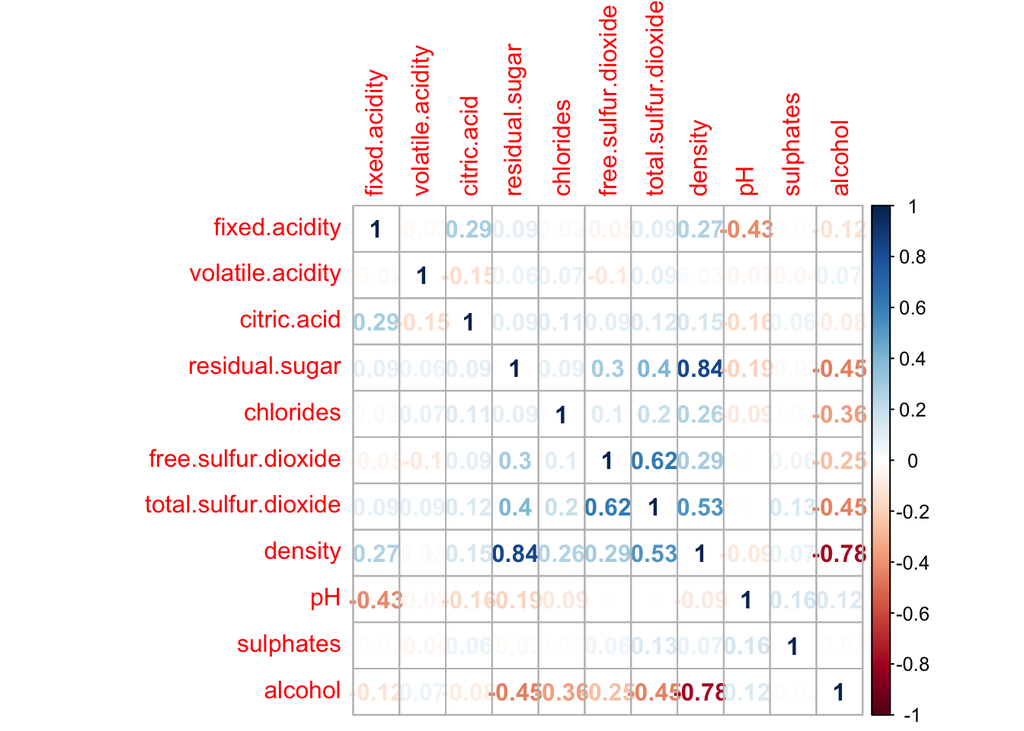

```r
corrplot(wine.cor, method="number") # I did this because I appreciate the visual
```

```r
# highest correlation:
# density & residual.sugar: 0.84
# density & alcohol: -0.78

# I found a cool SO thread on how to do this programmatically:
# https://stackoverflow.com/questions/7074246/show-correlations-as-an-ordered-list-not-as-a-large-matrix#7074856

# as.data.frame(as.table(wine.cor))

# install.packages("reshape")
library(reshape) # includes melt()

wine.cor.list <- wine.cor
wine.cor.list[wine.cor.list == 1] <- NA
wine.cor.list <- na.omit(melt(wine.cor.list))
wine.cor.list[order(-abs(wine.cor.list$value)),]
```

```
##                       X1                   X2         value
## 41               density       residual.sugar  0.8389664549
## 81        residual.sugar              density  0.8389664549
## 88               alcohol              density -0.7801376214
## 118              density              alcohol -0.7801376214
## 62  total.sulfur.dioxide  free.sulfur.dioxide  0.6155009650
## 72   free.sulfur.dioxide total.sulfur.dioxide  0.6155009650
## 74               density total.sulfur.dioxide  0.5298813239
## 84  total.sulfur.dioxide              density  0.5298813239
## 44               alcohol       residual.sugar -0.4506312220
## 114       residual.sugar              alcohol -0.4506312220
## 77               alcohol total.sulfur.dioxide -0.4488921021
## 117 total.sulfur.dioxide              alcohol -0.4488921021
## 9                     pH        fixed.acidity -0.4258582910
## 89         fixed.acidity                   pH -0.4258582910
```

[output cut: 96 more lines]

### 3. Graph the frequency distribution of wine quality .

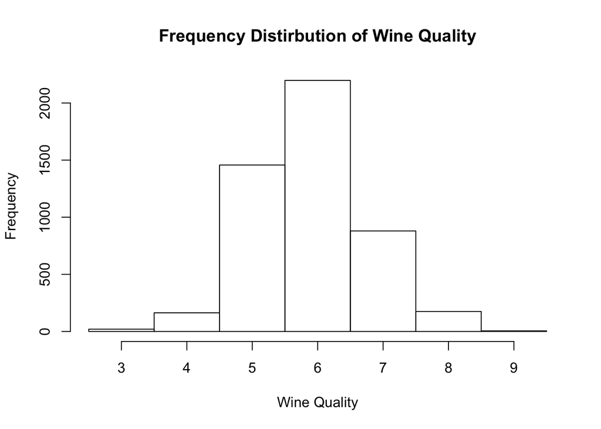

```r
hist(wine.df$quality, freq=T, breaks=seq(2.5,9.5,1), main="Frequency Distirbution of Wine Quality", xlab="Wine Quality")
```

### 4. Reduce the levels of rating for quality to three levels as high, medium and low.

```r
wine.df$quality <- cut(wine.df$quality, 3, labels=c("Low","Medium","High"))
table(wine.df$quality)
```

```
##
##    Low Medium   High
##   1640   3078    180
```

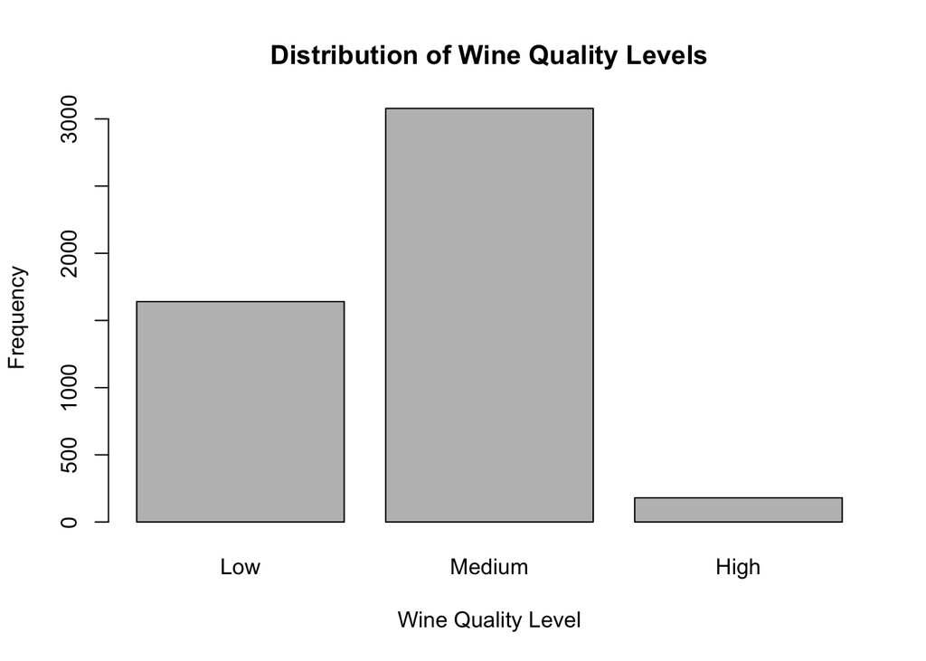

```r
plot(wine.df$quality, main="Distribution of Wine Quality Levels", xlab="Wine Quality Level", ylab="Frequency") # unequal distribution of class variables (potential class imbalance problem)
```

### 5. Normalize the data set.

```r
# scale() returns a matrix. Also requires numerical values
# (exclude class attribute (factor): column 12)
wine.df.norm <- as.data.frame(scale(wine.df[,-12], center=T, scale=T))
wine.df.norm <- cbind(wine.df.norm, wine.df[,12]) # Re-add class attribute
names(wine.df.norm)[12] <- names(wine.df)[12] # Re-name the class attribute
```

### 6. Divide the data to training and testing groups.

```r
# I wanted replicable results for discussion. Remove below call to set.seed() to
# re-introduce pseudo random numbers in division of test & training set.
set.seed(42)

wine.train_index <- sample(1:nrow(wine.df.norm), 0.7*nrow(wine.df.norm))
wine.train <- wine.df.norm[wine.train_index,]
wine.test <- wine.df.norm[-wine.train_index,]
(nrow(wine.df) == (nrow(wine.train) + nrow(wine.test))) # Did we include all observations?
```

```
## [1] TRUE
```

### 7. Use the KNN algorithm to predict the quality of wine using its attributes.

```r
library(class) # needed for knn()
# I chose to reference the test group directly in the following calls to knn().
# wine.train_labels <- wine.train$quality
# wine.test_labels <- wine.test$quality
#
# Note that subsetting & removing the attribute quality (wine.test[,-12]):
# done to separate class attribute from training & test sets.
# Explicitly defined as cl parameter.

wine.knn <- list(k3=factor(),k5=factor(),k7=factor())
wine.knn$k3 <- knn(train=wine.train[,-12], test=wine.test[,-12], cl=wine.train$quality, k=3, prob=T)
wine.knn$k5 <- knn(train=wine.train[,-12], test=wine.test[,-12], cl=wine.train$quality, k=5)
wine.knn$k15 <- knn(train=wine.train[-12], test=wine.test[,-12], cl=wine.train$quality, k=15)
```

### 8. Evaluate the model performance .

```r
library(gmodels) # Necessary for CrossTable()

# I prefer actual results along the top of the table: I find it easier to read
# This seems pretty standard, and is likewise on Wikipedia: https://en.wikipedia.org/wiki/Confusion_matrix
CrossTable(x=wine.knn$k3, y=wine.test$quality, prop.chisq = F)
```

```
##
##
##    Cell Contents
## |-------------------------|
## |                       N |
## |           N / Row Total |
## |           N / Col Total |
## |         N / Table Total |
## |-------------------------|
##
##
## Total Observations in Table:  1470
##
##
##              | wine.test$quality
##  wine.knn$k3 |       Low |    Medium |      High | Row Total |
## -------------|-----------|-----------|-----------|-----------|
##          Low |       305 |       161 |         4 |       470 |
##              |     0.649 |     0.343 |     0.009 |     0.320 |
##              |     0.642 |     0.171 |     0.074 |           |
##              |     0.207 |     0.110 |     0.003 |           |
## -------------|-----------|-----------|-----------|-----------|
##       Medium |       167 |       766 |        40 |       973 |
##              |     0.172 |     0.787 |     0.041 |     0.662 |
##              |     0.352 |     0.814 |     0.741 |           |
##              |     0.114 |     0.521 |     0.027 |           |
## -------------|-----------|-----------|-----------|-----------|
##         High |         3 |        14 |        10 |        27 |
##              |     0.111 |     0.519 |     0.370 |     0.018 |
##              |     0.006 |     0.015 |     0.185 |           |
##              |     0.002 |     0.010 |     0.007 |           |
## -------------|-----------|-----------|-----------|-----------|
## Column Total |       475 |       941 |        54 |      1470 |
##              |     0.323 |     0.640 |     0.037 |           |
## -------------|-----------|-----------|-----------|-----------|
##
##
```

```r
CrossTable(x=wine.knn$k5, y=wine.test$quality, prop.chisq = F)
```

```
##
##
##    Cell Contents
## |-------------------------|
## |                       N |
## |           N / Row Total |
## |           N / Col Total |
## |         N / Table Total |
## |-------------------------|
##
##
## Total Observations in Table:  1470
##
##
##              | wine.test$quality
##  wine.knn$k5 |       Low |    Medium |      High | Row Total |
## -------------|-----------|-----------|-----------|-----------|
##          Low |       301 |       153 |         2 |       456 |
##              |     0.660 |     0.336 |     0.004 |     0.310 |
##              |     0.634 |     0.163 |     0.037 |           |
##              |     0.205 |     0.104 |     0.001 |           |
## -------------|-----------|-----------|-----------|-----------|
##       Medium |       170 |       779 |        48 |       997 |
##              |     0.171 |     0.781 |     0.048 |     0.678 |
##              |     0.358 |     0.828 |     0.889 |           |
##              |     0.116 |     0.530 |     0.033 |           |
## -------------|-----------|-----------|-----------|-----------|
##         High |         4 |         9 |         4 |        17 |
##              |     0.235 |     0.529 |     0.235 |     0.012 |
##              |     0.008 |     0.010 |     0.074 |           |
##              |     0.003 |     0.006 |     0.003 |           |
## -------------|-----------|-----------|-----------|-----------|
## Column Total |       475 |       941 |        54 |      1470 |
##              |     0.323 |     0.640 |     0.037 |           |
## -------------|-----------|-----------|-----------|-----------|
##
##
```

```r
CrossTable(x=wine.knn$k15, y=wine.test$quality, prop.chisq = F)
```

```
##
##
##    Cell Contents
## |-------------------------|
## |                       N |
## |           N / Row Total |
## |           N / Col Total |
## |         N / Table Total |
## |-------------------------|
##
##
## Total Observations in Table:  1470
##
##
##              | wine.test$quality
## wine.knn$k15 |       Low |    Medium |      High | Row Total |
## -------------|-----------|-----------|-----------|-----------|
##          Low |       293 |       143 |         2 |       438 |
##              |     0.669 |     0.326 |     0.005 |     0.298 |
##              |     0.617 |     0.152 |     0.037 |           |
##              |     0.199 |     0.097 |     0.001 |           |
## -------------|-----------|-----------|-----------|-----------|
##       Medium |       182 |       798 |        52 |      1032 |
##              |     0.176 |     0.773 |     0.050 |     0.702 |
##              |     0.383 |     0.848 |     0.963 |           |
##              |     0.124 |     0.543 |     0.035 |           |
## -------------|-----------|-----------|-----------|-----------|
## Column Total |       475 |       941 |        54 |      1470 |
##              |     0.323 |     0.640 |     0.037 |           |
## -------------|-----------|-----------|-----------|-----------|
##
##
```

```r
# Different values of k produce very similar results with the best being a toss up between k=3 & k=5
# I think that overall this model performed acceptably. It would be interesting to compare to other
# models (Naive Bayes, Decesion Tree, etc) and see how it compares in terms of accuracy.
#
# I think another important concept that wasn't included in this assignment is the
# concept of "research question" and "metrics of success".
# For example, below I listed the True Positive rates for the three levels: low, medium and high.
# However, perhaps True Positives aren't the most important metrics for your research question.
# Maybe False Positives are a bigger issue, or False Negatives. This is context specific but extremely
# relevant with these types of models. For example, look at the classification of High Quality wines:
# The TP rates are 37%, 23% and 0% with k set to 3, and 15 respectively.
# That might not be considered very high depending on your research question.
#
# Also note the low success TP rate for a high k: 0%. This would seem like a result of the
# "majority vote" combined with a class imbalance problem. As there are so few Wines in
# the "high" category it is unlikely that with a higher K, who collects votes from more
# "Nearest Neighbors" there being enough votes in favour of the wine quality being "high".
# This is definitely an issue to be aware of when using these models.
#
# TP rates (k=3): 64.9%, 78.7%, 37.0% for Low, Medium & High respectively
#
# I also did a Prime Component Analysis (PCA) and ran the kNN model to compare with the above results.
# It produced a very marginal improvement in TP rates for k=3: 65.2%, 78.8%, and 40.0% for Low, Medium
# & High, respectively.
```

## Extra

### Visualization

I tried to plot the KNN output of this assignment visually and ran into some trouble I still believe this to be a great exercise but perhaps not ideal for this particular assignment.

### Some resources:

- https://cran.r-project.org/web/packages/ElemStatLearn/ElemStatLearn.pdf # pg 8: mixture.example examples
- https://stats.stackexchange.com/questions/21572/how-to-plot-decision-boundary-of-a-k-nearest-neighbor-classifier-from-elements-o/21602#21602
- https://stackoverflow.com/questions/31234621/variation-on-how-to-plot-decision-boundary-of-a-k-nearest-neighbor-classifier-f

I adapted my code as much as possible from the examples and discussion on Stack Overflow but in the end had to settle for a relatively straightforward cluster plot based on kNN algorithm results. The results of this attempt made me wonder if performing Dimensionality Reduction would help: it didn’t. My results are below. In the end I chose to plot pH vs. free.sulfur.dioxide because these are the least correlated factors in the dataset.

```r
require(dplyr)
```

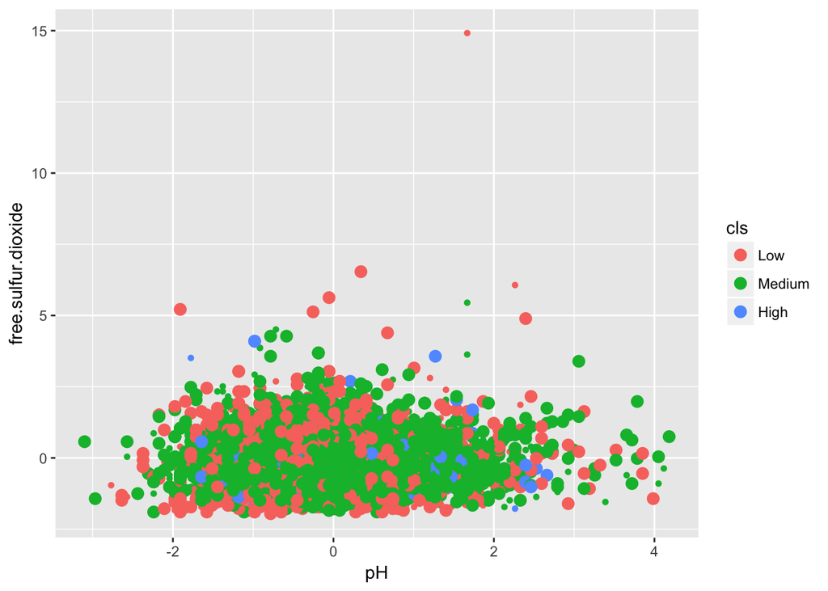

```r
classif <- wine.knn$k3
prob <- attr(classif, "prob")
wine.gf.df <- bind_rows(mutate(wine.test[,-12],
                               prob=prob,
                               cls="Low",
                               prob_cls=ifelse(classif==cls, 1, 0)),
                        mutate(wine.test[,-12],
                               prob=prob,
                               cls="Medium",
                               prob_cls=ifelse(classif==cls, 1, 0)),
                        mutate(wine.test[,-12],
                               prob=prob,
                               cls="High",
                               prob_cls=ifelse(classif==cls, 1, 0)))

# wine.gf.df.unq <- wine.gf.df[!duplicated(wine.gf.df[, c('pH', 'free.sulfur.dioxide')]), ]

require(ggplot2)
ggplot(wine.gf.df) +
  geom_point(aes(x=pH, y=free.sulfur.dioxide, col=cls),
             data=mutate(wine.test[,-12], cls=classif),
             size=1.2) +
  # geom_contour(aes(x=pH, y=free.sulfur.dioxide, z=prob_cls, group=cls, color=cols),
  #              bins=2,
  #              data=wine.gf.df.unq) +
  geom_point(aes(x=x, y=y, col=cls),
             size=3,
             data=data.frame(x=wine.train$pH, y=wine.train$free.sulfur.dioxide, cls=wine.train$quality))
```

## PCA

I decided to spend some more time on this dataset and applied PCA. My goal was the same as above; to organize the data in such a way to be able to create an effective visual. I was unsuccesful in that regard but did notice that the model performs better, with regards to the TP Rate, than without doing PCA.

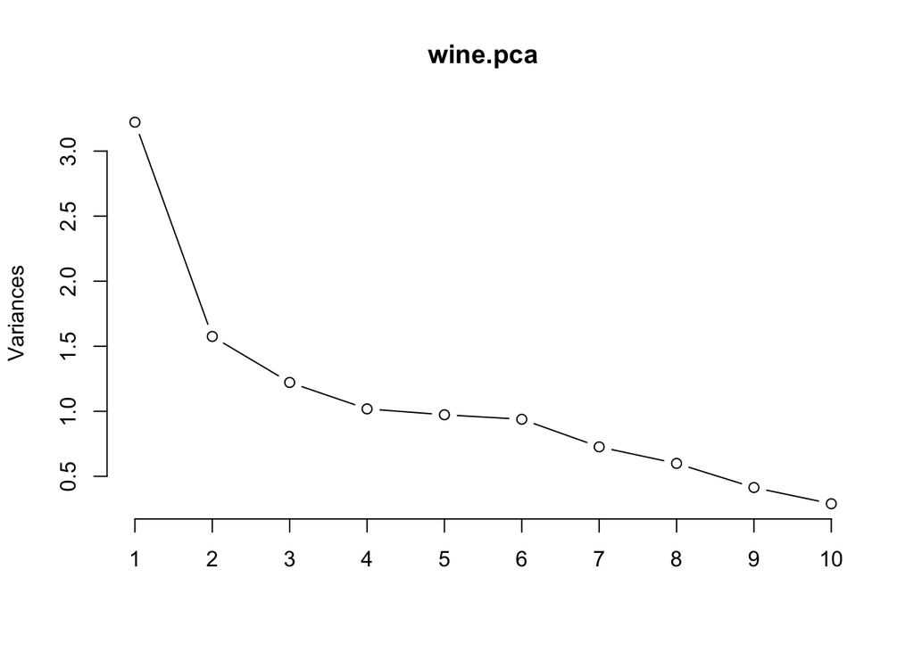

```r
wine.pca <- prcomp(wine.df[,-12], scale. = T, center = T)
screeplot(wine.pca, type="lines")
```

```r
wine.pca.knn <- knn(train=wine.pca$x[wine.train_index,], test=wine.pca$x[-wine.train_index,], cl=wine.df[wine.train_index,'quality'], k=3, prob=T)

CrossTable(x=wine.pca.knn, y=wine.df[-wine.train_index,'quality'], prop.chisq = F)
```

```
##
##
##    Cell Contents
## |-------------------------|
## |                       N |
## |           N / Row Total |
## |           N / Col Total |
## |         N / Table Total |
## |-------------------------|
##
##
## Total Observations in Table:  1470
##
##
##              | wine.df[-wine.train_index, "quality"]
## wine.pca.knn |       Low |    Medium |      High | Row Total |
## -------------|-----------|-----------|-----------|-----------|
##          Low |       306 |       160 |         3 |       469 |
##              |     0.652 |     0.341 |     0.006 |     0.319 |
##              |     0.644 |     0.170 |     0.056 |           |
##              |     0.208 |     0.109 |     0.002 |           |
## -------------|-----------|-----------|-----------|-----------|
##       Medium |       166 |       769 |        41 |       976 |
##              |     0.170 |     0.788 |     0.042 |     0.664 |
##              |     0.349 |     0.817 |     0.759 |           |
##              |     0.113 |     0.523 |     0.028 |           |
## -------------|-----------|-----------|-----------|-----------|
##         High |         3 |        12 |        10 |        25 |
##              |     0.120 |     0.480 |     0.400 |     0.017 |
##              |     0.006 |     0.013 |     0.185 |           |
##              |     0.002 |     0.008 |     0.007 |           |
## -------------|-----------|-----------|-----------|-----------|
## Column Total |       475 |       941 |        54 |      1470 |
##              |     0.323 |     0.640 |     0.037 |           |
## -------------|-----------|-----------|-----------|-----------|
##
##
```

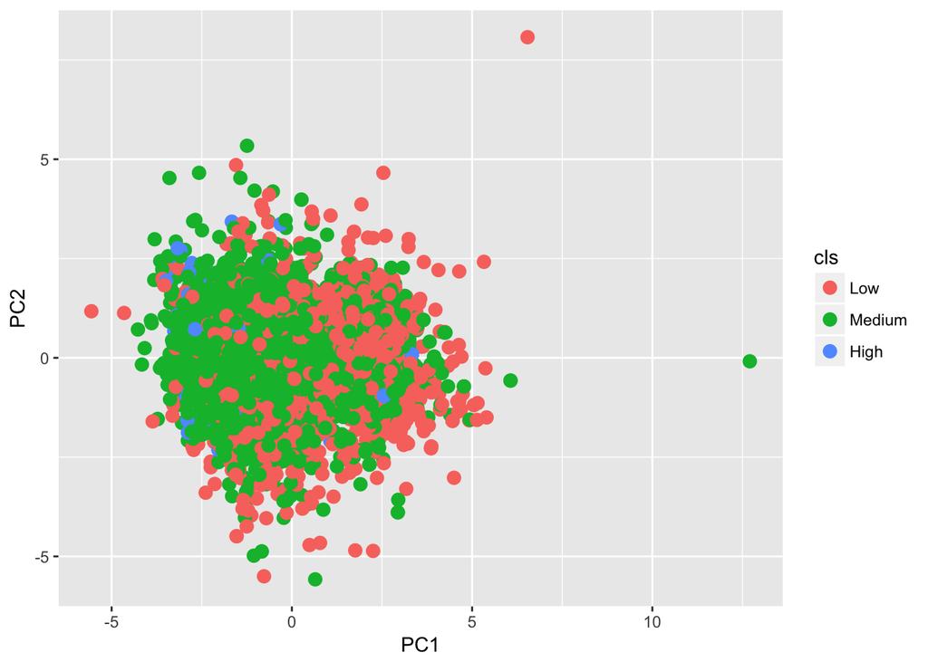

```r
prob <- attr(wine.pca.knn, "prob")
test <- as.data.frame(wine.pca$x)

wine.pca.gf.df <- bind_rows(mutate(test[-wine.train_index,],
                               prob=prob,
                               cls="Low",
                               prob_cls=ifelse(wine.pca.knn==cls, 1, 0)),
                        mutate(test[-wine.train_index,],
                               prob=prob,
                               cls="Medium",
                               prob_cls=ifelse(wine.pca.knn==cls, 1, 0)),
                        mutate(test[-wine.train_index,],
                               prob=prob,
                               cls="High",
                               prob_cls=ifelse(wine.pca.knn==cls, 1, 0)))


wine.pca.gf.df$cols <- vector(length=nrow(wine.pca.gf.df))
wine.pca.gf.df$cols[wine.pca.gf.df$cls == 'Low'] <- 'c'
wine.pca.gf.df$cols[wine.pca.gf.df$cls == 'Medium'] <- 's'
wine.pca.gf.df$cols[wine.pca.gf.df$cls == 'High'] <- 'v'

ggplot(wine.gf.df) +
  geom_point(aes(x=PC1, y=PC2, col=cls),
             data=mutate(test[-wine.train_index,], cls=wine.pca.knn),
             size=1.2) +
  # geom_contour(aes(x=PC1, y=PC2, z=prob_cls, group=cls, color=cols),
  #              bins=2,
  #              data=wine.pca.gf.df) +
  geom_point(aes(x=x, y=y, col=cls),
             size=3,
             data=data.frame(x=wine.pca$x[,1], y=wine.pca$x[,2], cls=wine.df$quality))
```

Save your R codes in an RMD file. Send your RMD and PDF files to the course shell.